# Assignment 2: Data visualization

Tamas Nagy

You will have to create 3 plots based on the datasets and instructions detailed below. You will find the plots themeselves in the `assignments/assignment_2_plots`. Your task is to write the code that will reproduce the plots as closely as possible.

# Skills needed to solve this assignment

- Using R and RStudio, reading data
- Reporting using RMarkdown
- Using Git and Github (for submitting the task)
- Data manipulation (e.g. dplyr, tidyr), and working with factors (forcats)
- Data visualization (ggplot2)

## Task 1: Climbing expeditions

The 2020-09-22 TidyTueday datasets are about climbing expeditions. From the three datasets, use the “expeditions”. Reproduce the plot below! Notice a few things:

- Use `forcats::fct_lump()` to get the 15 most frequent peaks, and drop the “Other” category.
- The bars are ordered by the sum of all expeditions (use `fct_reorder()`).
- The bar colors use the viridis palette and light theme.

```
## Rows: 10,364
## Columns: 16
## $ expedition_id      <chr> "ANN260101", "ANN269301", "ANN273101", "ANN278301",…
## $ peak_id            <chr> "ANN2", "ANN2", "ANN2", "ANN2", "ANN2", "ANN2", "AN…
## $ peak_name          <chr> "Annapurna II", "Annapurna II", "Annapurna II", "An…
## $ year               <dbl> 1960, 1969, 1973, 1978, 1979, 1980, 1980, 1981, 198…
## $ season             <chr> "Spring", "Autumn", "Spring", "Autumn", "Autumn", "…
## $ basecamp_date      <date> 1960-03-15, 1969-09-25, 1973-03-16, 1978-09-08, NA…
## $ highpoint_date     <date> 1960-05-17, 1969-10-22, 1973-05-06, 1978-10-02, 19…
## $ termination_date   <date> NA, 1969-10-26, NA, 1978-10-05, 1979-10-20, 1980-0…
## $ termination_reason <chr> "Success (main peak)", "Success (main peak)", "Succ…
## $ highpoint_metres   <dbl> 7937, 7937, 7937, 7000, 7160, 7000, 7250, 6400, 740…
## $ members            <dbl> 10, 10, 6, 2, 3, 6, 7, 19, 9, 5, 5, 5, 6, 4, 3, 4, …
## $ member_deaths      <dbl> 0, 0, 0, 0, 0, 1, 0, 0, 1, 0, 1, 0, 0, 0, 0, 0, 0, …
## $ hired_staff        <dbl> 9, 0, 8, 0, 0, 2, 2, 0, 3, 0, 0, 3, 4, 2, 0, 2, 5, …
## $ hired_staff_deaths <dbl> 0, 0, 0, 0, 0, 0, 0, 0, 0, 0, 0, 0, 0, 0, 0, 0, 0, …
## $ oxygen_used        <lgl> TRUE, FALSE, FALSE, FALSE, FALSE, FALSE, FALSE, FAL…
## $ trekking_agency    <chr> NA, NA, NA, NA, NA, NA, NA, NA, NA, NA, NA, "Kunga"…
```

```
## # A tibble: 20 × 2
##    peak_name           n
##    <chr>           <int>
##  1 Everest          2149
##  2 Ama Dablam       1366
##  3 Cho Oyu          1332
##  4 Manaslu           632
##  5 Lhotse            429
##  6 Dhaulagiri I      383
##  7 Makalu            356
##  8 Baruntse          308
##  9 Pumori            265
## 10 Annapurna I       243
## 11 Kangchenjunga     184
## 12 Himlung Himal     148
## 13 Annapurna IV       97
## 14 Putha Hiunchuli    91
## 15 Tilicho            86
## 16 Nuptse             64
## 17 Tukuche            62
## 18 Jannu              52
## 19 Langtang Lirung    49
## 20 Makalu II          47
```

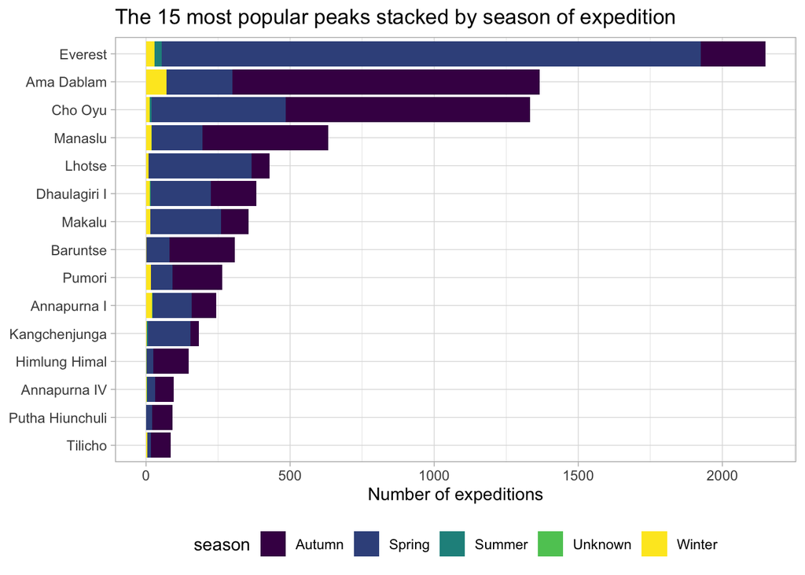

## Task 2: PhDs awarded

The 2019-02-19 TidyTueday dataset is about phd-s awarded by year and field. There is only one dataset, it is called `phd_by_field`. Reproduce the plot below!

Notes:

- First you have to aggregate the data to count all phd-s by broad fields.
- To make the x axis breaks pretty, use `scales::pretty_breaks()`, to make the y axis labels comma formatted, use `scales::comma_format()`.
- The line size is 1.2, the colors are from the brewer “Dark2” palette. The theme is set to minimal.

```
## Rows: 3,370
## Columns: 5
## $ broad_field <chr> "Life sciences", "Life sciences", "Life sciences", "Life s…
## $ major_field <chr> "Agricultural sciences and natural resources", "Agricultur…
## $ field       <chr> "Agricultural economics", "Agricultural and horticultural …
## $ year        <dbl> 2008, 2008, 2008, 2008, 2008, 2008, 2008, 2008, 2008, 2008…
## $ n_phds      <dbl> 111, 28, 3, 68, 41, 18, 77, 182, 52, 96, 41, 32, 44, 17, 5…
```

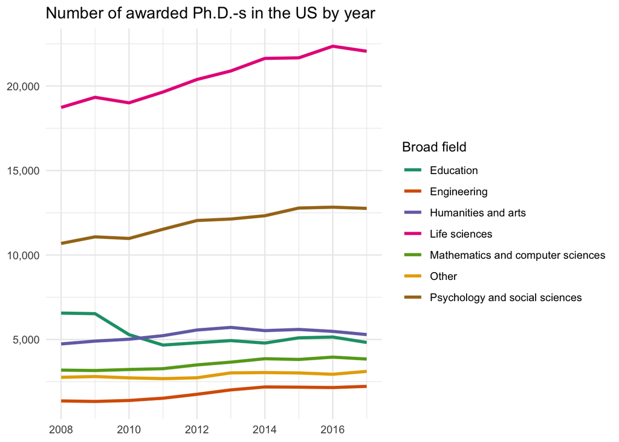

## Task 3: Commute in the US

The 2019-11-05 TidyTueday dataset is about commuting to work in each city in the US by bike or on foot. There is only one dataset, it is called `commute`. Reproduce the plot below!

Notes:

- First you have to aggregate the data to count all commutes by state.
- Both axis scales are log transformed and the labels comma formatted, using `scales::comma_format()`
- The point size is 2, . The theme is set to light.

```
## Rows: 3,496
## Columns: 9
## $ city         <chr> "Aberdeen city", "Acworth city", "Addison village", "Adel…
## $ state        <chr> "South Dakota", "Georgia", "Illinois", "California", "Mic…
## $ city_size    <chr> "Small", "Small", "Small", "Small", "Small", "Small", "Sm…
## $ mode         <chr> "Bike", "Bike", "Bike", "Bike", "Bike", "Bike", "Bike", "…
## $ n            <dbl> 110, 0, 43, 0, 121, 0, 84, 23, 0, 576, 35, 77, 419, 281, …
## $ percent      <dbl> 0.8, 0.0, 0.2, 0.0, 1.5, 0.0, 0.8, 0.2, 0.0, 1.5, 0.3, 0.…
## $ moe          <dbl> 0.5, 0.4, 0.3, 0.5, 1.0, 0.2, 1.1, 0.3, 0.2, 0.4, 0.2, 0.…
## $ state_abb    <chr> "SD", "GA", "IL", "CA", "MI", "MA", "CA", "SC", "AL", "CA…
## $ state_region <chr> "North Central", "South", "North Central", "West", "North…
```

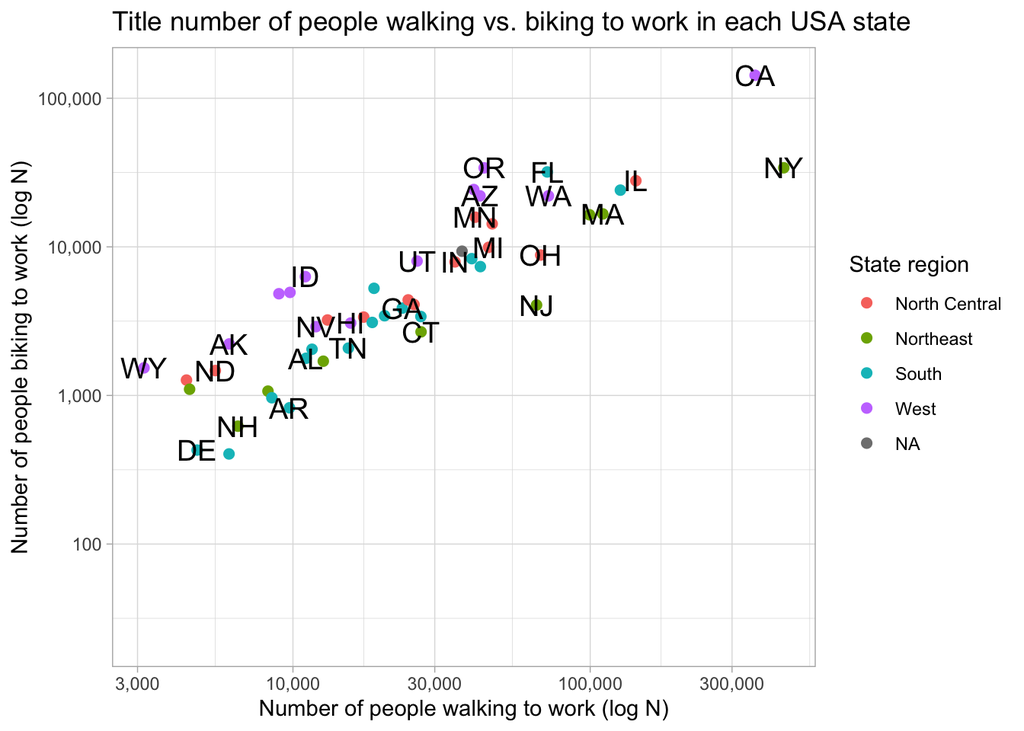